# Practical Machine Learning Course Project

## Background

Using devices such as Jawbone Up, Nike FuelBand, and Fitbit it is now possible to collect a large amount of data about personal activity relatively inexpensively. These type of devices are part of the quantified self movement – a group of enthusiasts who take measurements about themselves regularly to improve their health, to find patterns in their behavior, or because they are tech geeks. One thing that people regularly do is quantify how much of a particular activity they do, but they rarely quantify how well they do it. In this project, your goal will be to use data from accelerometers on the belt, forearm, arm, and dumbell of 6 participants. They were asked to perform barbell lifts correctly and incorrectly in 5 different ways. More information is available from the website here: [link to the website](http://web.archive.org/web/20161224072740/http:/groupware.les.inf.puc-rio.br/har)

Six young health participants were asked to perform one set of 10 repetitions of the Unilateral Dumbbell Biceps Curl in five different fashions: exactly according to the specification (Class A), throwing the elbows to the front (Class B), lifting the dumbbell only halfway (Class C), lowering the dumbbell only halfway (Class D) and throwing the hips to the front (Class E).

Class A corresponds to the specified execution of the exercise, while the other 4 classes correspond to common mistakes. Participants were supervised by an experienced weight lifter to make sure the execution complied to the manner they were supposed to simulate. The exercises were performed by six male participants aged between 20-28 years, with little weight lifting experience. We made sure that all participants could easily simulate the mistakes in a safe and controlled manner by using a relatively light dumbbell (1.25kg).

Read more: http:/groupware.les.inf.puc-rio.br/har#dataset#ixzz4TjqH0SaY

## Downlaoding and loading the dataset

```r
if(!file.exists('pml-training.csv')){
download.file('https://d396qusza40orc.cloudfront.net/predmachlearn/pml-training.csv',destfile = './pml-training.csv', method = 'curl')
}

Pml_Training <- read.csv('pml-training.csv')

if(!file.exists('pml-test.csv')){
download.file('https://d396qusza40orc.cloudfront.net/predmachlearn/pml-testing.csv',destfile = './pml-test.csv', method = 'curl')
}

Pml_Testing <- read.csv('pml-test.csv')
```

### Exploring the training dataset

```r
names(Pml_Training)
```

```
##   [1] "X"                        "user_name"
##   [3] "raw_timestamp_part_1"     "raw_timestamp_part_2"
##   [5] "cvtd_timestamp"           "new_window"
##   [7] "num_window"               "roll_belt"
##   [9] "pitch_belt"               "yaw_belt"
##  [11] "total_accel_belt"         "kurtosis_roll_belt"
##  [13] "kurtosis_picth_belt"      "kurtosis_yaw_belt"
##  [15] "skewness_roll_belt"       "skewness_roll_belt.1"
##  [17] "skewness_yaw_belt"        "max_roll_belt"
##  [19] "max_picth_belt"           "max_yaw_belt"
##  [21] "min_roll_belt"            "min_pitch_belt"
##  [23] "min_yaw_belt"             "amplitude_roll_belt"
##  [25] "amplitude_pitch_belt"     "amplitude_yaw_belt"
##  [27] "var_total_accel_belt"     "avg_roll_belt"
##  [29] "stddev_roll_belt"         "var_roll_belt"
```

[output cut: 65 more lines]

So we have 160 variables, classe being the one which we have to predict.

It would be good to remove those variables which have near zero variance.

```r
library(caret)
nzvar <- nearZeroVar(Pml_Training)
Pml_Training <- Pml_Training[,-nzvar]
Pml_Testing <- Pml_Testing[,-nzvar]

names(Pml_Training)
```

```
##   [1] "X"                        "user_name"
##   [3] "raw_timestamp_part_1"     "raw_timestamp_part_2"
##   [5] "cvtd_timestamp"           "num_window"
##   [7] "roll_belt"                "pitch_belt"
##   [9] "yaw_belt"                 "total_accel_belt"
##  [11] "max_roll_belt"            "max_picth_belt"
##  [13] "min_roll_belt"            "min_pitch_belt"
##  [15] "amplitude_roll_belt"      "amplitude_pitch_belt"
##  [17] "var_total_accel_belt"     "avg_roll_belt"
##  [19] "stddev_roll_belt"         "var_roll_belt"
##  [21] "avg_pitch_belt"           "stddev_pitch_belt"
##  [23] "var_pitch_belt"           "avg_yaw_belt"
##  [25] "stddev_yaw_belt"          "var_yaw_belt"
##  [27] "gyros_belt_x"             "gyros_belt_y"
##  [29] "gyros_belt_z"             "accel_belt_x"
```

[output cut: 35 more lines]

So now we have 100 variables.

We still have many variables which contain NA’s. We will remove them too.

```r
Pml_Training <- Pml_Training[,colSums(is.na(Pml_Training)) < .05*nrow(Pml_Training)]
Pml_Testing <- Pml_Testing[,colSums(is.na(Pml_Testing)) < .05*nrow(Pml_Testing)]
```

So we are now left with 59 variables to predict on.

We still have some variables who can’t be used to predict the classe variable.

```r
Pml_Training <- Pml_Training[,-(1:6)]
Pml_Testing <- Pml_Testing[,-(1:6)]
```

Let’s try to get a good idea on how much information is given by the independent variables about the dependent variable which is classe in this class. We will use information.gain() from FSelector to get this information.

```r
library(FSelector)
order(information.gain(classe~., Pml_Training), decreasing = TRUE)
```

```
##  [1]  3  2  1 38 40 37 10 39 36 13 12 41 27 34  7 29 32 35  4 30 28 14 18 51  9
## [26] 24 11 50 47  8  6 21 25 22 26 16 19 31 48 23 52  5 45 49 42 17 15 43 33 46
## [51] 44 20
```

From this we see that roll_belt, pitch_belt, yaw_belt are some of the variable that have high value associated with Classe variable.

Since there are 53 variables, correlation plot will be more easy and useful to interpre than correlation matrix.

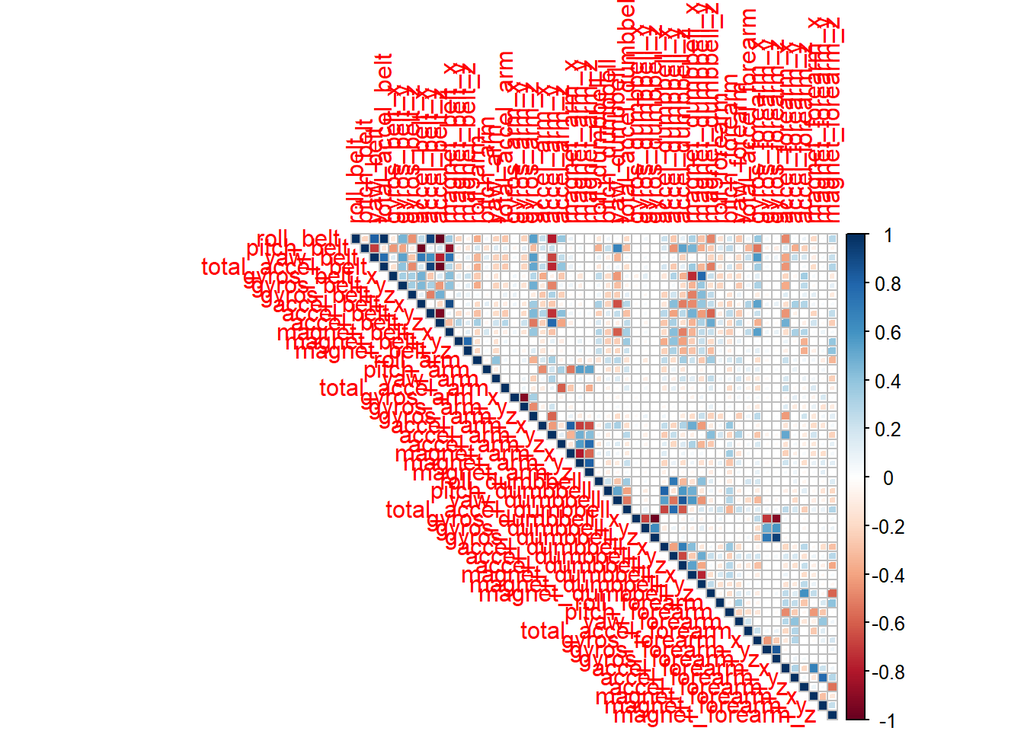

```r
library(corrplot)
corrplot(cor(Pml_Training[,-53]), method = 'square', type = 'upper')
```

Here, dark shade represents high correlation between two variables. In our plot, we see that there are very few dark squares indicating that there are few correlated variables. Hence this is not very useful.

## Prediction Models

First we will break our training dataset into two parts, in the ratio of 3:1, where we would use 3/4th of the data to train the model and 1/4th to validate and then finally using to predict

```r
intrain <- createDataPartition(y = Pml_Training$classe, p = 0.75, list = F)
Training <- Pml_Training[intrain,]
Validating <- Pml_Training[-intrain,]
```

We will now apply the following models to our dataset. 1.) Random Forest 2.) Classification Trees 3.) Generalized Boosted Model

A Confusion Matrix is used at the end of each analysis to better visualize the accuracy of the models.

### Random Forest

```r
set.seed(69)

RandF <- train(classe~., data = Training, method = 'rf', trControl = trainControl(method = 'cv', number = 5))
print(RandF$finalModel)
```

```
##
## Call:
##  randomForest(x = x, y = y, mtry = param$mtry)
##                Type of random forest: classification
##                      Number of trees: 500
## No. of variables tried at each split: 2
##
##         OOB estimate of  error rate: 0.72%
## Confusion matrix:
##      A    B    C    D    E  class.error
## A 4184    1    0    0    0 0.0002389486
## B   17 2822    9    0    0 0.0091292135
## C    0   20 2545    2    0 0.0085703155
## D    0    0   45 2365    2 0.0194859038
## E    0    0    2    8 2696 0.0036954915
```

Predicting with Random Forest

```r
predictRandF <- predict(RandF, newdata=Validating)
confusionMatrix(predictRandF, factor(Validating$classe))
```

```
## Confusion Matrix and Statistics
##
##           Reference
## Prediction    A    B    C    D    E
##          A 1393    3    0    0    0
##          B    2  943   10    0    0
##          C    0    3  844   18    4
##          D    0    0    1  786    1
##          E    0    0    0    0  896
##
## Overall Statistics
##
##                Accuracy : 0.9914
##                  95% CI : (0.9884, 0.9938)
##     No Information Rate : 0.2845
##     P-Value [Acc > NIR] : < 2.2e-16
##
##                   Kappa : 0.9892
##
##  Mcnemar's Test P-Value : NA
##
## Statistics by Class:
##
##                      Class: A Class: B Class: C Class: D Class: E
## Sensitivity            0.9986   0.9937   0.9871   0.9776   0.9945
## Specificity            0.9991   0.9970   0.9938   0.9995   1.0000
## Pos Pred Value         0.9979   0.9874   0.9712   0.9975   1.0000
## Neg Pred Value         0.9994   0.9985   0.9973   0.9956   0.9988
## Prevalence             0.2845   0.1935   0.1743   0.1639   0.1837
## Detection Rate         0.2841   0.1923   0.1721   0.1603   0.1827
## Detection Prevalence   0.2847   0.1947   0.1772   0.1607   0.1827
## Balanced Accuracy      0.9989   0.9953   0.9905   0.9886   0.9972
```

#### Accuracy is .99 which gives our Out of sample error rate equal to 0.01.

### Classification Trees

```r
set.seed(69)

ClassT <- train(classe~., data = Training, method = 'rpart')
print(ClassT$finalModel)
```

```
## n= 14718
##
## node), split, n, loss, yval, (yprob)
##       * denotes terminal node
##
##  1) root 14718 10533 A (0.28 0.19 0.17 0.16 0.18)
##    2) roll_belt< 130.5 13471  9297 A (0.31 0.21 0.19 0.18 0.11)
##      4) pitch_forearm< -34.35 1187     5 A (1 0.0042 0 0 0) *
##      5) pitch_forearm>=-34.35 12284  9292 A (0.24 0.23 0.21 0.2 0.12)
##       10) magnet_dumbbell_y< 439.5 10400  7471 A (0.28 0.18 0.24 0.19 0.11)
##         20) roll_forearm< 122.5 6472  3849 A (0.41 0.18 0.19 0.16 0.062) *
##         21) roll_forearm>=122.5 3928  2651 C (0.078 0.18 0.33 0.23 0.18) *
##       11) magnet_dumbbell_y>=439.5 1884   916 B (0.033 0.51 0.042 0.23 0.19) *
##    3) roll_belt>=130.5 1247    11 E (0.0088 0 0 0 0.99) *
```

Predicting with Classification Trees

```r
predictClassT <- predict(ClassT, newdata = Validating)
confusionMatrix(predictClassT, factor(Validating$classe))
```

```
## Confusion Matrix and Statistics
##
##           Reference
## Prediction    A    B    C    D    E
##          A 1267  382  376  370  125
##          B   18  318   28  144  137
##          C  107  249  451  290  244
##          D    0    0    0    0    0
##          E    3    0    0    0  395
##
## Overall Statistics
##
##                Accuracy : 0.4957
##                  95% CI : (0.4816, 0.5098)
##     No Information Rate : 0.2845
##     P-Value [Acc > NIR] : < 2.2e-16
##
##                   Kappa : 0.3415
##
##  Mcnemar's Test P-Value : NA
##
## Statistics by Class:
##
##                      Class: A Class: B Class: C Class: D Class: E
## Sensitivity            0.9082  0.33509  0.52749   0.0000  0.43840
## Specificity            0.6429  0.91732  0.78019   1.0000  0.99925
## Pos Pred Value         0.5028  0.49302  0.33632      NaN  0.99246
## Neg Pred Value         0.9463  0.85184  0.88661   0.8361  0.88771
## Prevalence             0.2845  0.19352  0.17435   0.1639  0.18373
## Detection Rate         0.2584  0.06485  0.09197   0.0000  0.08055
## Detection Prevalence   0.5139  0.13153  0.27345   0.0000  0.08116
## Balanced Accuracy      0.7756  0.62620  0.65384   0.5000  0.71883
```

#### Accuracy is .49 which gives our out of sample error rate is .51 which is quite high.

### Boosting

```r
set.seed(69)
Boost <- train(classe~., data = Training, method = 'gbm', verbose = FALSE, trControl = trainControl(method = 'repeatedcv', number = 5))
print(Boost$finalModel)
```

```
## A gradient boosted model with multinomial loss function.
## 150 iterations were performed.
## There were 52 predictors of which 52 had non-zero influence.
```

Predicting with Boosting

```r
predictBoost <- predict(Boost, newdata = Validating)
confusionMatrix(predictBoost, factor(Validating$classe))
```

```
## Confusion Matrix and Statistics
##
##           Reference
## Prediction    A    B    C    D    E
##          A 1369   31    0    1    0
##          B   17  892   29    3   11
##          C    6   25  819   39   11
##          D    2    1    7  756   10
##          E    1    0    0    5  869
##
## Overall Statistics
##
##                Accuracy : 0.9594
##                  95% CI : (0.9535, 0.9648)
##     No Information Rate : 0.2845
##     P-Value [Acc > NIR] : < 2.2e-16
##
##                   Kappa : 0.9487
##
##  Mcnemar's Test P-Value : 6.547e-09
##
## Statistics by Class:
##
##                      Class: A Class: B Class: C Class: D Class: E
## Sensitivity            0.9814   0.9399   0.9579   0.9403   0.9645
## Specificity            0.9909   0.9848   0.9800   0.9951   0.9985
## Pos Pred Value         0.9772   0.9370   0.9100   0.9742   0.9931
## Neg Pred Value         0.9926   0.9856   0.9910   0.9884   0.9921
## Prevalence             0.2845   0.1935   0.1743   0.1639   0.1837
## Detection Rate         0.2792   0.1819   0.1670   0.1542   0.1772
## Detection Prevalence   0.2857   0.1941   0.1835   0.1582   0.1784
## Balanced Accuracy      0.9861   0.9624   0.9689   0.9677   0.9815
```

#### Accuracy is .96 which gives our out of sample error rate is .04 which is again quite small.

So we compare the accuracy of the three model, it is clear that Random Forest has the highest accuracy. So we will use it for our test set.

```r
predict_final <- predict(RandF, newdata = Pml_Testing)
predict_final
```

```
##  [1] B A B A A E D B A A B C B A E E A B B B
## Levels: A B C D E
```